# How Do You Maximize Profit in the Horror Industry?

Author

Nicholas Abraham

## Horror Film Industry Continues to Grow

The film industry is a very competitive field, with many different genres that appeal to different audiences. One of these genres is the very popular Horror Films. Horror is the 6th most popular movie genre in the US and Canada from 1994 - 2024, bringing in a revenue of $15.96 billion[^1]. This genre has a growing competition, with a steady increase in the amount of horror films released each year, the amount of releases per year has more than doubled from 26 in 2015, to 55 in 2024[^2]. Horror movies are no longer played just at Halloween time. The genre has grown out of spooky season and is watched all year long. This interest allows for more opportunity of profit for filmmakers. In 2025 two of the three highest-grossing original titles of the year (through October) have been horror movies[^3]. So in this increasing market how can filmmakers maximize their profit? Making a film is big investment, and filmmakers need to do everything they can to maximize their chances at turning profit. By taking a look at “Horror Movies” (which you can read about here[^4]) this question will be explored.

## Data

```r
library(tidyverse)
library(dplyr)
library(gt)
library(readxl)
library(scales)
library(patchwork)
movies <- read_csv("horror_movies.csv")
```

```r
movies_w_budgets <- movies %>%
  filter(budget > 0,
         revenue > 0) %>%
  mutate(profit = revenue - budget)
```

First, all the movies that have no budget or revenue must be removed from the data set, as they are considered NA data and cannot be used. If the zeros are used it will effect the averages and skew the data.

## Does a Higher Budget Help Secure More Revenue and Profits?

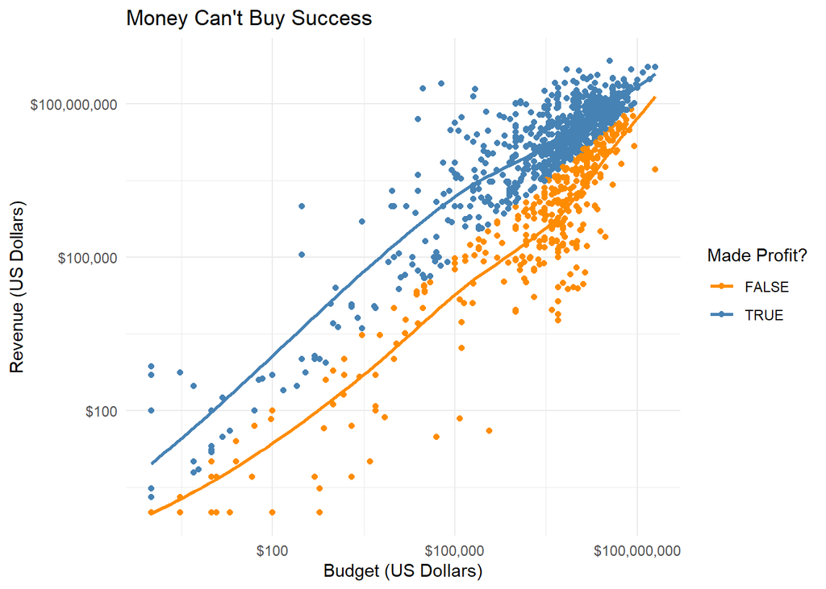

```r
ggplot(movies_w_budgets,
       aes(x = budget,
           y = revenue,
           color = (profit > 0))) +
  geom_point() +
  geom_smooth(se = FALSE) +
  scale_y_log10(labels = label_dollar()) +
  scale_x_log10(labels = label_dollar()) +
  scale_color_manual(values = c("darkorange", "steelblue")) +
  theme_minimal() +
  labs(x = "Budget (US Dollars)",
       y = "Revenue (US Dollars)",
       color = "Made Profit?",
       title = "Money Can't Buy Success")
```

It can be seen that there is a positive linear correlation between a higher budget leading to a higher revenue. However, it is clear that a higher budget does not guarantee profit. Profit can be made with any budget a company may have, and they must also be careful as it is always possible that they don’t make profit, even with higher budgets.

It should be noted that if a film “broke even” (profit of 0) it is collected as not making profit (“FALSE”).

**Also Note** the scale of the axes, they are on a logarithmic scale, *not* linear.

## Runtimes Effect Profit

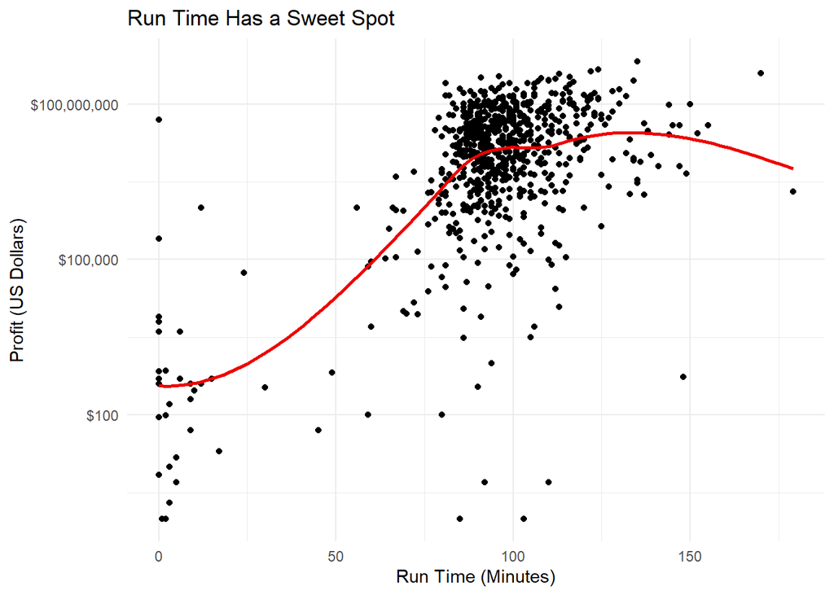

```r
movies_profit <- movies_w_budgets %>%
  filter(profit > 0)

ggplot(movies_profit,
       aes(x = runtime,
           y = profit)) +
  geom_point() +
  geom_smooth(se = FALSE, color = "red2") +
  scale_y_log10(label = label_dollar()) +
  theme_minimal() +
  labs(x = "Run Time (Minutes)",
       y = "Profit (US Dollars)",
       title = "Run Time Has a Sweet Spot")
```

It can be seen by this graph that, while profits have some variation, there is a condensed spot of high profit at the ~85 to ~115 minutes length. Majority of movies at this length turn high profits. This shows that in order to maximize profit, a run time of 85 - 115 minutes is desired. You can see that there is still high profit movies outside this range, but the sample size is less. These movies above the range do turn high profit. So a movie longer than 115 minutes may be considered, but less than 85 minutes should be avoided, as they have less profit.

**Note:** Movies that made no profit have been omitted from this graph because this graph focus on movies that have made a profit, in order to maximize the profit. The negative and 0 values of profit would skew the data distort the visual trend of the graph, and this trend is not goal of this graph. Also, The scale of the y-axis is *not* linear, it is logarithmic.

```r
movies_runtime <- movies_w_budgets %>%
  mutate(runtime_group = case_when(runtime < 85 ~ "<85 min",
                                   runtime <= 115 ~ "85-115 min",
                                   TRUE ~ ">115 min"))

runtime_summary <- movies_runtime %>%
  group_by(runtime_group) %>%
  summarize(avg_profit = mean(profit, na.rm = TRUE),
            median_profit = median(profit, na.rm = TRUE),
            n_movies = n(),
            pct_profitable = mean(profit > 0) * 100) %>%
  gt() %>%
  fmt_currency(columns = c(avg_profit, median_profit),
               currency = "USD") %>%
  fmt_number(columns = c(pct_profitable),
             decimals = 1) %>%
  cols_label(avg_profit = "Average Profit",
             median_profit = "Median Profit",
             runtime_group = "Run Time (Min)",
             n_movies = "Number of Movies",
             pct_profitable = "% of Movies Profitable") %>%
  tab_header(title = "Profit by Runtime") %>%
  tab_style(style = list(cell_fill(color = "lightgreen")),
            locations = cells_body(rows = runtime_group == "85-115 min"))

runtime_summary
```

Profit by Runtime

| Run Time (Min) | Average Profit | Median Profit | Number of Movies | % of Movies Profitable |
| --- | --- | --- | --- | --- |
| 85-115 min | $25,405,371.28 | $5,268,096.50 | 804 | 67.4 |
| <85 min | $6,224,200.72 | $102.00 | 189 | 57.1 |
| >115 min | $65,284,841.23 | $21,446,533.00 | 105 | 79.0 |

This table shows a numerical representation of the previous graph. Highlighted in green is the “Sweet spot” that was seen in “Run Time Has a Sweet Spot”. The sweet spot on the table does not exactly align with that of the graph, this is because the table shows raw profits in USD, while the plot uses a log scale to show the trend. As a result, extreme outliers in profit appear larger in the table than in the visual trend. The outliers in the table effect the averages more than in the plot. The sample sizes for each section should also be noted; the sample size for the sweet spot is way larger than the other two rows, meaning the other two rows are more susceptible to outliers. The table shows the sweet spot also makes high profit.

**Note:** The numerical data was calculated *with* the movies that did not turn a profit, unlike the previous graph, these negative values and zeros have an effect on the averages, changing the sweet spot that was observed in the graph.

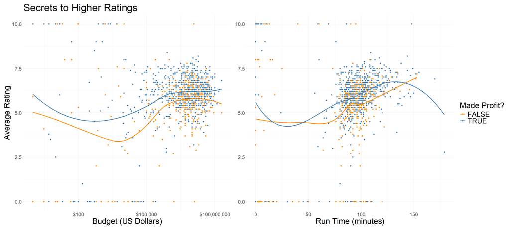

```r
num_1 <- ggplot(movies_w_budgets,
                aes(y = vote_average,
                x = budget,
                color = (profit > 0))) +
                geom_point(show.legend = FALSE) +
                geom_smooth(se = FALSE,
                            show.legend = FALSE) +
                scale_x_log10(label = label_dollar()) +
                theme_minimal() +
                scale_color_manual(values = c("darkorange", "steelblue")) +
                theme(axis.title = element_text(size = 22),
                      axis.text = element_text(size = 14),
                      plot.title = element_text(size = 28)) +
                labs(y = "Average Rating",
                     x = "Budget (US Dollars)",
                     title = "Secrets to Higher Ratings")

num_2 <- ggplot(movies_w_budgets,
                aes(y = vote_average,
                x = runtime,
                color = (profit > 0))) +
                geom_point() +
                geom_smooth(se = FALSE) +
                theme_minimal() +
                scale_color_manual(values = c("darkorange", "steelblue")) +
                theme(axis.title = element_text(size = 22),
                      axis.text = element_text(size = 14),
                      legend.text = element_text(size = 20),
                      legend.title = element_text(size = 22)) +
                labs(y = NULL,
                     x = "Run Time (minutes)",
                     color = "Made Profit?")

num_1 + num_2
```

**Note:** The scale of the x-axis, are on a logarithmic scale, *not* linear (for the budget, run time *is* linear).

## Advertising Effects

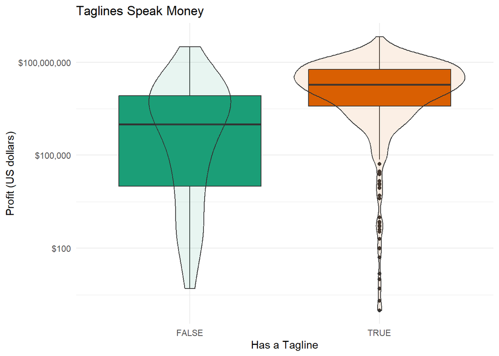

```r
movies_tagline <- movies_w_budgets %>%
  mutate(has_tagline = !is.na(tagline))

ggplot(movies_tagline,
       aes(x = has_tagline,
           y = profit,
           fill = has_tagline)) +
  geom_boxplot(show.legend = FALSE) +
  geom_violin(alpha = .1,
              show.legend = FALSE) +
  scale_y_log10(labels = label_dollar()) +
  theme_minimal() +
  scale_fill_brewer(palette = "Dark2") +
  labs(x = "Has a Tagline",
       y = "Profit (US dollars)",
       title = "Taglines Speak Money")
```

Many movies in the data set do not have a tagline, does this impact their profits? The movies were put into two groups, if it has a tagline or not. This graph does not take into account if it is a *good* tagline, just the fact it has one. It is seen from the box plot that the average profit of movies with a tagline is greater than those without. The overlapping violin plot helps support that idea, by showing the density of movies is condensed at higher profits for taglines. For the movies without a tagline it is observed they have less profit, and majority of the density is at lower profits. A tagline is very impactful to a movies profits, and movies should follow along this trend to maximize their profits.

**Note:** The scale of the y-axis is *not* linear, it is logarithmic.

```r
movies_table <- movies_w_budgets %>%
  mutate(has_tagline = case_when(!is.na(tagline) & tagline != "" ~ "Has Tagline",
                                 TRUE ~ "No Tagline"),
         is_franchise = case_when(!is.na(collection)
                                  & collection != "" ~ "Franchise",
                                  TRUE ~ "Non-Franchise"))

tagline_table <- movies_table %>%
  group_by(has_tagline) %>%
  summarize(avg_profit = mean(profit, na.rm = TRUE),
            median_profit = median(profit, na.rm = TRUE),
            n_movies = n(),
            pct_profitable = mean(profit > 0) * 100) %>%
  gt() %>%
  fmt_currency(columns = c(avg_profit, median_profit),
               currency = "USD",
               decimals = 0) %>%
  fmt_number(columns = c(pct_profitable), decimals = 1) %>%
  cols_label(has_tagline = "Tagline Status",
            avg_profit = "Average Profit",
            median_profit = "Median Profit",
            n_movies = "Number of Movies",
            pct_profitable = "% of Movies Profitable") %>%
  tab_header(title = "Profits by Tagline Presence") %>%
  tab_style(style = list(cell_fill(color = "lightgreen")),
            locations = cells_body(rows = has_tagline == "Has Tagline"))

tagline_table
```

Profits by Tagline Presence

| Tagline Status | Average Profit | Median Profit | Number of Movies | % of Movies Profitable |
| --- | --- | --- | --- | --- |
| Has Tagline | $29,110,018 | $4,790,000 | 957 | 69.4 |
| No Tagline | $4,247,612 | $0 | 141 | 48.9 |

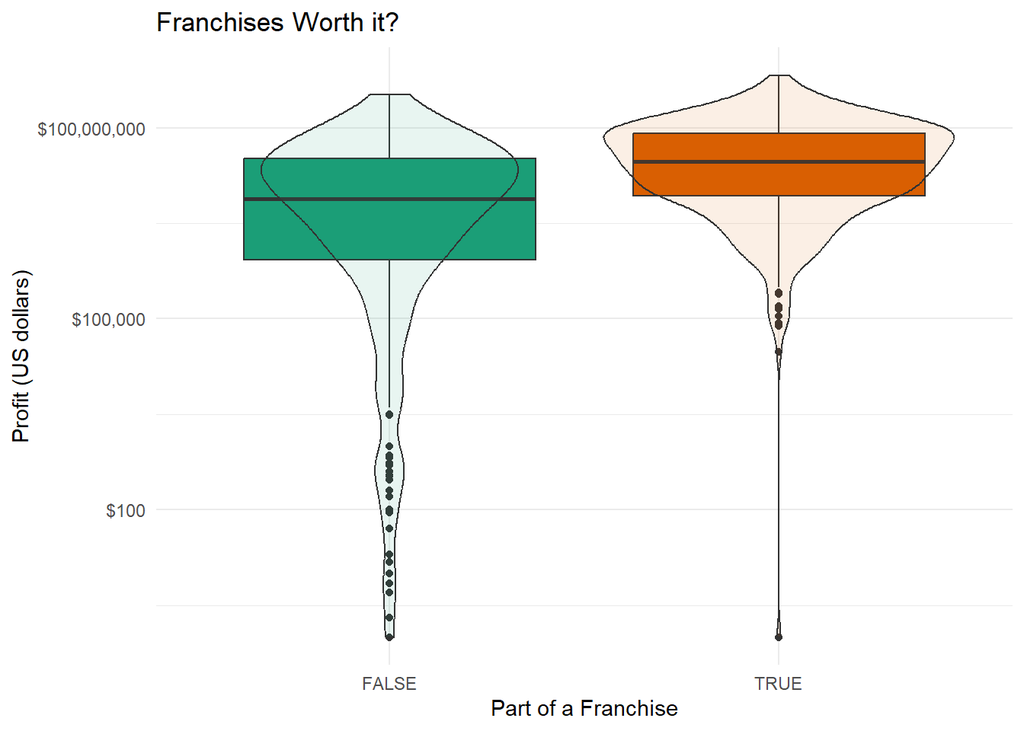

```r
movies_fran <- movies_w_budgets %>%
  mutate(made_profit = profit > 0,
    is_franchise = !is.na(collection))

ggplot(movies_fran,
       aes(x = is_franchise,
           y = profit,
           fill = is_franchise)) +
  geom_boxplot(show.legend = FALSE) +
  geom_violin(alpha = .1,
              show.legend = FALSE) +
  scale_y_log10(labels = label_dollar()) +
  theme_minimal() +
  scale_fill_brewer(palette = "Dark2") +
  labs(x = "Part of a Franchise",
       y = "Profit (US dollars)",
       title = "Franchises Worth it?")
```

**Note:** The scale of the y-axis is *not* linear, it is logarithmic.

```r
franchise_table <- movies_table %>%
  group_by(is_franchise) %>%
  summarize(avg_profit = mean(profit, na.rm = TRUE),
            median_profit = median(profit, na.rm = TRUE),
            n_movies = n(),
            pct_profitable = mean(profit > 0) * 100) %>%
  gt() %>%
  fmt_currency(columns = c(avg_profit, median_profit),
               currency = "USD",
               decimals = 0) %>%
  fmt_number(columns = c(pct_profitable),
             decimals = 1) %>%
  cols_label(is_franchise = "Franchise Status",
             avg_profit = "Average Profit",
             median_profit = "Median Profit",
             n_movies = "Number of Movies",
             pct_profitable = "% of Movies Profitable") %>%
  tab_header(title = "Profits by Franchise Status") %>%
  tab_style(style = list(cell_fill(color = "lightgreen")),
    locations = cells_body(rows = is_franchise == "Franchise"))

franchise_table
```

Profits by Franchise Status

| Franchise Status | Average Profit | Median Profit | Number of Movies | % of Movies Profitable |
| --- | --- | --- | --- | --- |
| Franchise | $50,887,740 | $21,906,625 | 398 | 88.2 |
| Non-Franchise | $11,719,829 | $860 | 700 | 54.6 |

## So What Maximizes Profits?

It is important to know that you don’t need a high budget to create a profit. Higher budgets are correlated to a higher revenue, but you can turn a profit, and lose money, at all ranges of budget. Higher budget doesn’t improve your probability of making a profit VS losing money, but it can help bring in more revenue.

## Footnotes

[^1]: “Top genres in the United States and Canada between 1995 to 2024, by total box office revenue” [Statista.com](https://www.statista.com/topics/12896/horror-movies/?srsltid=AfmBOoq76DWNqHsCFu9z-6a3A-ISm3qR53Ol_QcqQ6A-iUUlenopz5je#editorsPicks)
[^2]: “Number of horror movies released in the United States and Canada between 2000 and 2024”[Statista.com](https://www.statista.com/topics/12896/horror-movies/?srsltid=AfmBOoq76DWNqHsCFu9z-6a3A-ISm3qR53Ol_QcqQ6A-iUUlenopz5je#editorsPicks)
[^3]: “Horror Never Dies: What Keeps Audiences Coming Back for More” [nrgmr.com](https://www.nrgmr.com/our-thinking/entertainment/horror-never-dies-what-keeps-audiences-coming-back-for-more/)
[^4]: Information about Horror Movies data set [Github](https://github.com/tashapiro/horror-movies?tab=readme-ov-file)